# QK Box 11.5

Hey et al. (2020) studied the effect of artificial light at night (ALAN) on the growth of a wildflower species (*Asclepias syriaca*) in an outdoor field experiment. The plant, a species of milkweed, is an important host plant for caterpillars of the monarch butterfly.

They used a split-plot design for their experiment. The between-plots factor was ALAN, with five plots receiving artificial light and five control plots with the same set-up but only receiving ambient light. The sub-plots were 11 L small pots and there were two within-plot factors arranged in a crossed design; planting density (one or three plants per pot) and soil moisture (weekly addition of water vs no watering). There were four pots in each plot, so each combination of density and moisture had a single pot; the design is unreplicated at the sub-plot level. The response variable was total biomass (root and shoot) per pant in each pot, averaged across the plants within the higher density pots.

[figure not shown]

*Asclepias syriaca*. Cbaile19, CC0, via Wikimedia Commons

The paper is [here](https://doi.org/10.1007/s00442-020-04679-9)

Hey, M. H., DiBiase, E., Roach, D. A., Carr, D. E. & Haynes, K. J. (2020). Interactions between artificial light at night, soil moisture, and plant density affect the growth of a perennial wildflower. *Oecologia*, 193, 503-10.

### Preliminaries

First, load the required packages (afex, car, lattice, lme4, lmerTest, nlme, VCA, ez, emmeans, Rmisc, MuMIn)

Import heymean data file (heymean.csv)

```r
heymean <- read.csv("../data/heymean.csv")
heymean
```

| plot | pot | id | light | water | density | finaldam | dwtotal |
| --- | --- | --- | --- | --- | --- | --- | --- |
| 1 | 3 | 1A | Lit | Water | Low | 3.00 | 0.560 |
| 1 | 4 | 1B | Lit | NW | High | 1.67 | 0.837 |
| 1 | 2 | 1E | Lit | NW | Low | NA | 0.050 |
| 1 | 1 | 1F | Lit | Water | High | 3.00 | 0.900 |
| 2 | 1 | 2A | Lit | Water | Low | 2.00 | 0.700 |
| 2 | 2 | 2B | Lit | NW | High | 2.00 | 0.503 |
| 2 | 3 | 2E | Lit | NW | Low | 5.00 | 0.530 |
| 2 | 4 | 2F | Lit | Water | High | 3.67 | 0.483 |
| 3 | 2 | 3A | Control | Water | Low | 2.00 | 0.820 |
| 3 | 4 | 3B | Control | NW | High | 2.33 | 0.793 |

[output cut: 30 more lines]

Set contrasts from afex

Make plot a factor

```r
set_sum_contrasts()
```

```
## setting contr.sum globally: options(contrasts=c('contr.sum', 'contr.poly'))
```

```r
heymean$plot <- factor(heymean$plot)
```

Check residuals by leaving out error term

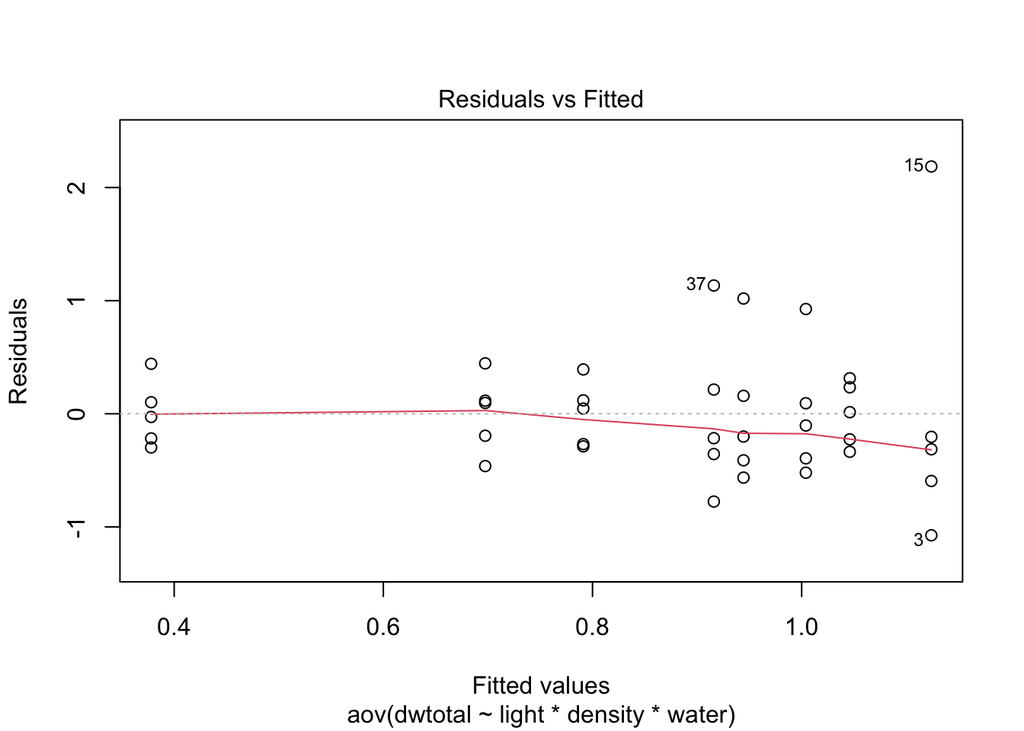

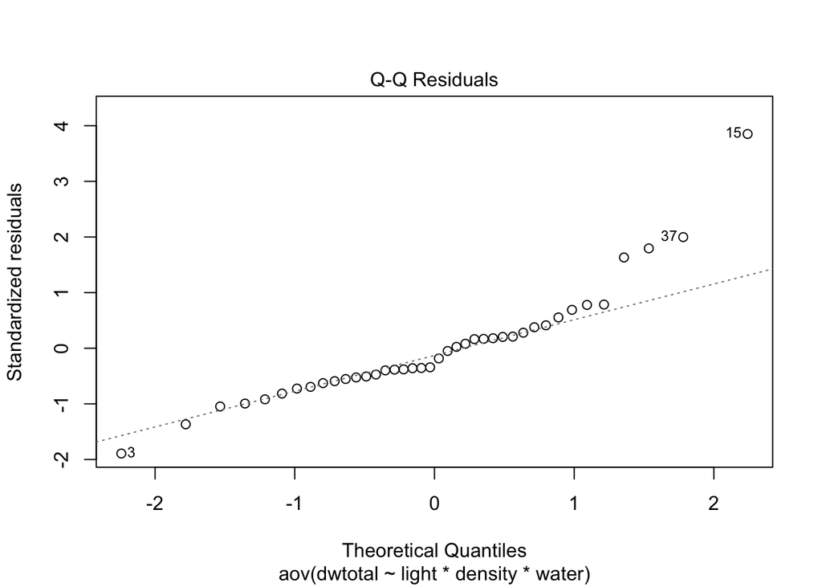

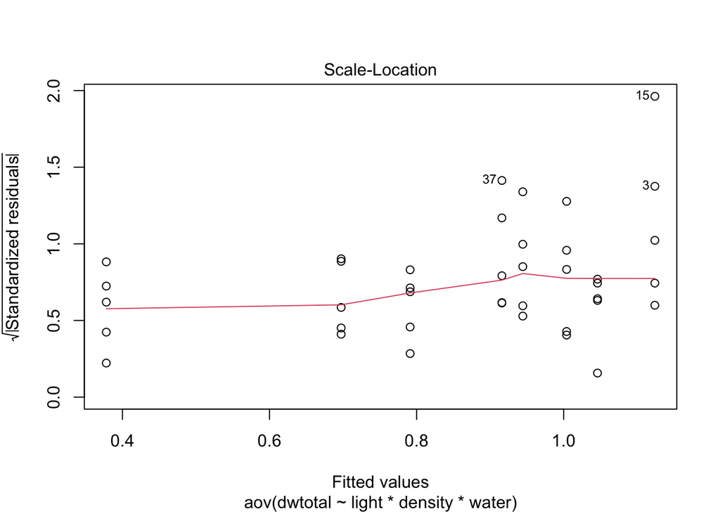

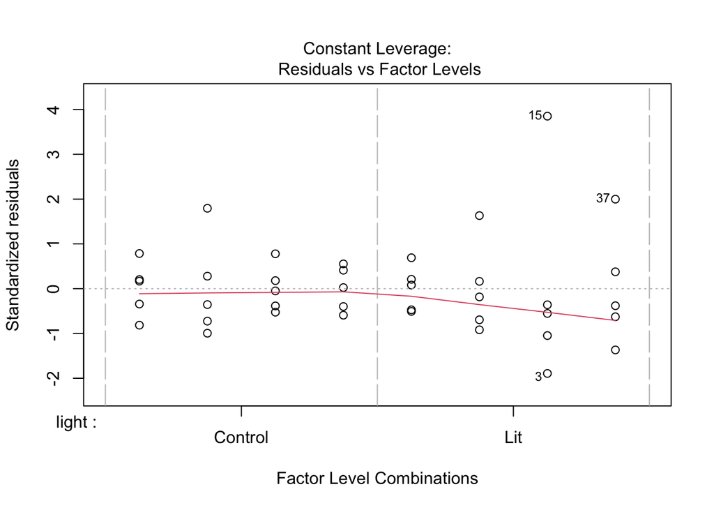

```r
hey1.aov <- aov(dwtotal~light*density*water, heymean)
plot(hey1.aov)
```

See if transformation improves the residuals

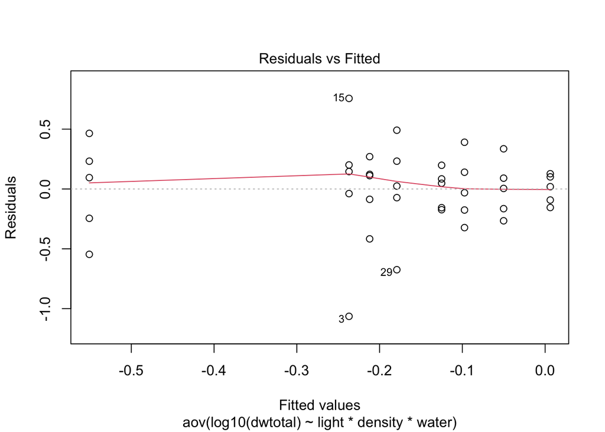

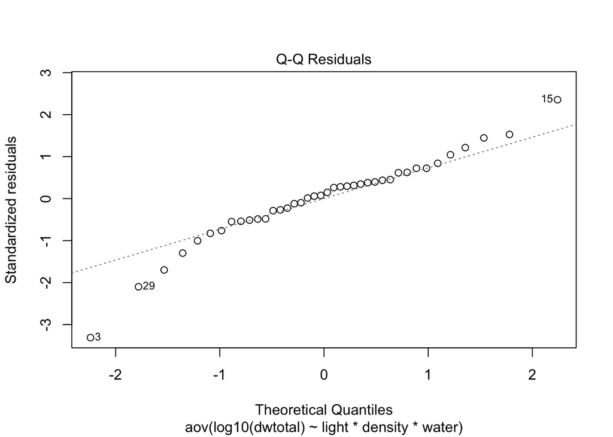

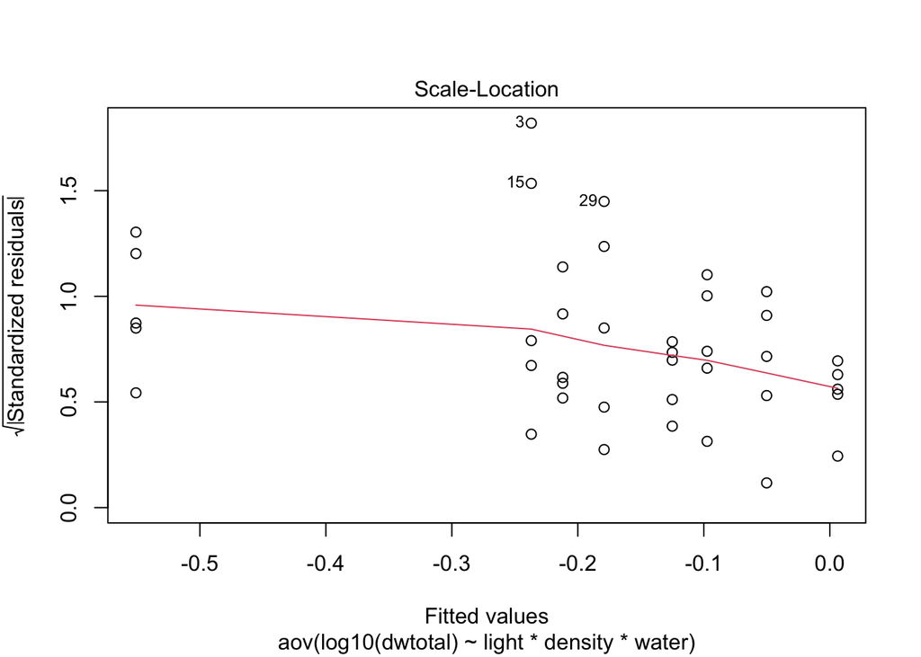

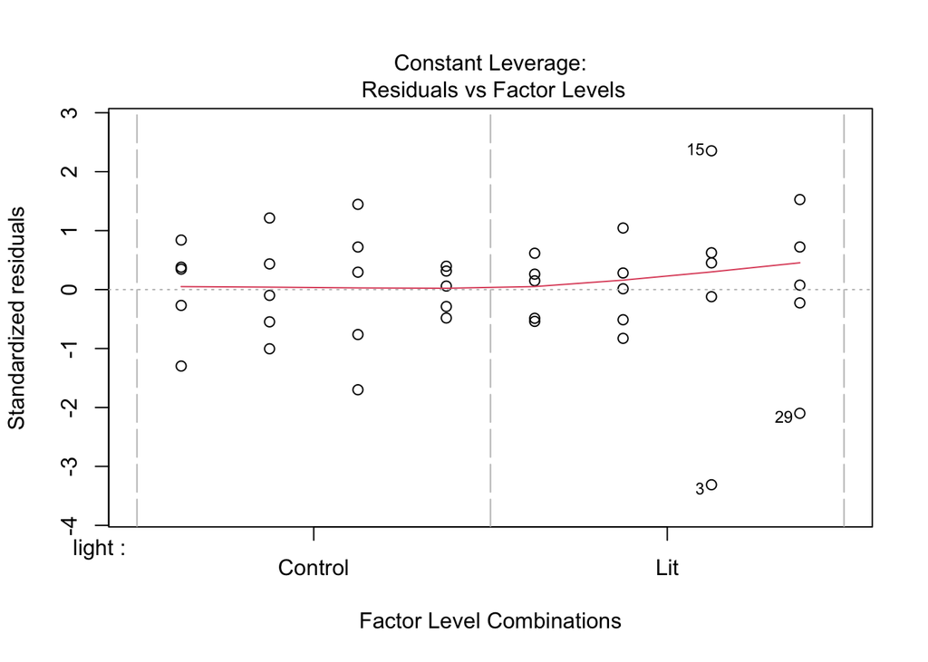

```r
hey2.aov <- aov(log10(dwtotal)~light*density*water, heymean)
plot(hey2.aov)
```

Some improvement in plot; outliers still present but transform response

**Note** Biomass is always positive, so we don’t really need to add anything before transforming. Hey et al. used a log(x+1) transformation, so we’ll do the same here for consistency. As an exercise, you could modify the next line of code to remove the +1 and rerun the model-fitting to see how much difference there is.

```r
heymean$ldwtotal <- log10(heymean$dwtotal+1)
```

## Fit factorial split-plot with separate within-plot error terms

```r
hey3.aov <- aov(ldwtotal~light*density*water+Error(plot/(density*water)), heymean)
summary(hey3.aov)
```

```
##
## Error: plot
##           Df  Sum Sq Mean Sq F value Pr(>F)
## light      1 0.01205 0.01205    0.33  0.582
## Residuals  8 0.29251 0.03656
##
## Error: plot:density
##               Df  Sum Sq  Mean Sq F value Pr(>F)
## density        1 0.00212 0.002119   0.207  0.661
## light:density  1 0.00172 0.001717   0.168  0.693
## Residuals      8 0.08198 0.010248
##
## Error: plot:water
##             Df  Sum Sq Mean Sq F value Pr(>F)
## water        1 0.03857 0.03857   4.381 0.0697 .
## light:water  1 0.02579 0.02579   2.930 0.1253
## Residuals    8 0.07042 0.00880
## ---
## Signif. codes:  0 '***' 0.001 '**' 0.01 '*' 0.05 '.' 0.1 ' ' 1
##
## Error: plot:density:water
##                     Df  Sum Sq  Mean Sq F value Pr(>F)
## density:water        1 0.00289 0.002891   0.291  0.605
## light:density:water  1 0.02112 0.021118   2.123  0.183
## Residuals            8 0.07960 0.009949
```

## Fit equivalent mixed effects model

```r
hey1.lmer <- lmer(ldwtotal~light+density+water+light*density+light*water+density*water+light*density*water+(1|plot)+(1|plot:density)+(1|plot:water), REML=TRUE, heymean)
```

```
## boundary (singular) fit: see help('isSingular')
```

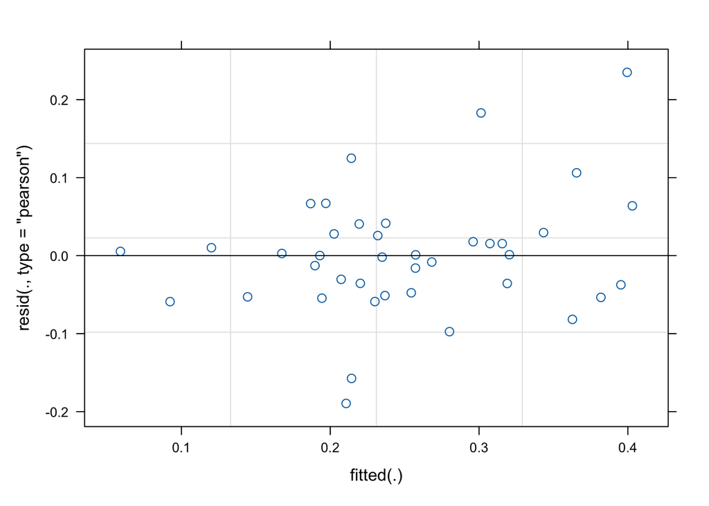

```r
plot(hey1.lmer)
```

residuals OK

```r
summary(hey1.lmer, ddf="Kenward-Roger")
```

```
## Linear mixed model fit by REML. t-tests use Kenward-Roger's method [
## lmerModLmerTest]
## Formula: ldwtotal ~ light + density + water + light * density + light *
##     water + density * water + light * density * water + (1 |
##     plot) + (1 | plot:density) + (1 | plot:water)
##    Data: heymean
##
## REML criterion at convergence: -17.5
##
## Scaled residuals:
##      Min       1Q   Median       3Q      Max
## -1.95701 -0.50107  0.00563  0.29210  2.42659
##
## Random effects:
##  Groups       Name        Variance Std.Dev.
##  plot:water   (Intercept) 0.000000 0.00000
##  plot:density (Intercept) 0.000436 0.02088
##  plot         (Intercept) 0.006579 0.08111
##  Residual                 0.009376 0.09683
## Number of obs: 40, groups:  plot:water, 20; plot:density, 20; plot, 10
##
## Fixed effects:
##                         Estimate Std. Error        df t value Pr(>|t|)
## (Intercept)             0.250820   0.030234  8.000000   8.296 3.36e-05 ***
## light1                 -0.017357   0.030234  8.000000  -0.574   0.5817
## density1                0.007278   0.016006  8.000000   0.455   0.6614
## water1                 -0.031051   0.015310  8.000000  -2.028   0.0771 .
## light1:density1         0.006551   0.016006  8.000000   0.409   0.6931
## light1:water1          -0.025394   0.015310  8.000000  -1.659   0.1358
## density1:water1         0.008501   0.015310  8.000000   0.555   0.5939
## light1:density1:water1  0.022977   0.015310  8.000000   1.501   0.1718
## ---
## Signif. codes:  0 '***' 0.001 '**' 0.01 '*' 0.05 '.' 0.1 ' ' 1
##
## Correlation of Fixed Effects:
##             (Intr) light1 dnsty1 water1 lght1:d1 lght1:w1 dns1:1
## light1      0.000
## density1    0.000  0.000
## water1      0.000  0.000  0.000
## lght1:dnst1 0.000  0.000  0.000  0.000
## light1:wtr1 0.000  0.000  0.000  0.000  0.000
## dnsty1:wtr1 0.000  0.000  0.000  0.000  0.000    0.000
## lght1:dn1:1 0.000  0.000  0.000  0.000  0.000    0.000    0.000
## optimizer (nloptwrap) convergence code: 0 (OK)
## boundary (singular) fit: see help('isSingular')
```

```r
anova(hey1.lmer, ddf="Kenward-Roger")
```

|  | Sum Sq | Mean Sq | NumDF | DenDF | F value | Pr(>F) |
| --- | --- | --- | --- | --- | --- | --- |
| light | 0.003090185 | 0.003090185 | 1 | 8 | 0.3295856 | 0.58168094 |
| density | 0.001938650 | 0.001938650 | 1 | 8 | 0.2067680 | 0.66139755 |
| water | 0.038567071 | 0.038567071 | 1 | 8 | 4.1133953 | 0.07707804 |
| light:density | 0.001570556 | 0.001570556 | 1 | 8 | 0.1675086 | 0.69307408 |
| light:water | 0.025793435 | 0.025793435 | 1 | 8 | 2.7510151 | 0.13577768 |
| density:water | 0.002890987 | 0.002890987 | 1 | 8 | 0.3083401 | 0.59388323 |
| light:density:water | 0.021117753 | 0.021117753 | 1 | 8 | 2.2523273 | 0.17180676 |

### Get variance components

```r
hey1.ci <- confint.merMod(hey1.lmer, oldNames=FALSE)
```

```
## Computing profile confidence intervals ...
```

```r
hey1.vc <- (hey1.ci)^2
print(hey1.vc)
```

```
##                                    2.5 %       97.5 %
## sd_(Intercept)|plot:water   0.000000e+00 6.336251e-03
## sd_(Intercept)|plot:density 0.000000e+00 6.909441e-03
## sd_(Intercept)|plot         3.078737e-04 1.840161e-02
## sigma                       4.370303e-03 1.331556e-02
## (Intercept)                 3.705582e-02 9.550811e-02
## light1                      5.727154e-03 1.670322e-03
## density1                    5.620900e-04 1.464252e-03
## water1                      3.460255e-03 1.075047e-05
## light1:density1             5.971058e-04 1.409119e-03
## light1:water1               2.826661e-03 5.658622e-06
## density1:water1             3.713823e-04 1.315793e-03
## light1:density1:water1      2.299879e-05 2.575505e-03
```

### Compare this model to model with no plot by density and moisture interactions

```r
hey1a.lmer <- lmer(ldwtotal~light+density+water+light*density+light*water+density*water+light*density*water+(1|plot)+(1|plot:density)+(1|plot:water), REML=FALSE, heymean)
```

```
## boundary (singular) fit: see help('isSingular')
```

```r
hey2.lmer <- lmer(ldwtotal~light*density*water+(1|plot), REML=FALSE, heymean)
anova(hey1a.lmer, hey2.lmer)
```

|  | npar | AIC | BIC | logLik | deviance | Chisq | Df | Pr(>Chisq) |
| --- | --- | --- | --- | --- | --- | --- | --- | --- |
| hey2.lmer | 10 | -47.66982 | -30.78103 | 33.83491 | -67.66982 | NA | NA | NA |
| hey1a.lmer | 12 | -43.69644 | -23.42988 | 33.84822 | -67.69644 | 0.02661342 | 2 | 0.9867814 |

```r
AICc(hey1a.lmer, hey2.lmer)
```

|  | df | AICc |
| --- | --- | --- |
| hey1a.lmer | 12 | -32.14088 |
| hey2.lmer | 10 | -40.08362 |

Simpler model fits equally well

```r
hey2a.lmer <- lmer(ldwtotal~light*density*water+(1|plot), REML=TRUE, heymean)
summary(hey2a.lmer, ddf="Kenward-Roger")
```

```
## Linear mixed model fit by REML. t-tests use Kenward-Roger's method [
## lmerModLmerTest]
## Formula: ldwtotal ~ light * density * water + (1 | plot)
##    Data: heymean
##
## REML criterion at convergence: -17.5
##
## Scaled residuals:
##      Min       1Q   Median       3Q      Max
## -2.00419 -0.45039 -0.02124  0.29623  2.44986
##
## Random effects:
##  Groups   Name        Variance Std.Dev.
##  plot     (Intercept) 0.006724 0.08200
##  Residual             0.009667 0.09832
## Number of obs: 40, groups:  plot, 10
##
## Fixed effects:
##                         Estimate Std. Error        df t value Pr(>|t|)
## (Intercept)             0.250820   0.030234  8.000000   8.296 3.36e-05 ***
## light1                 -0.017357   0.030234  8.000000  -0.574   0.5817
## density1                0.007278   0.015546 24.000000   0.468   0.6439
## water1                 -0.031051   0.015546 24.000000  -1.997   0.0572 .
## light1:density1         0.006551   0.015546 24.000000   0.421   0.6772
## light1:water1          -0.025394   0.015546 24.000000  -1.633   0.1154
## density1:water1         0.008501   0.015546 24.000000   0.547   0.5895
## light1:density1:water1  0.022977   0.015546 24.000000   1.478   0.1524
## ---
## Signif. codes:  0 '***' 0.001 '**' 0.01 '*' 0.05 '.' 0.1 ' ' 1
##
## Correlation of Fixed Effects:
##             (Intr) light1 dnsty1 water1 lght1:d1 lght1:w1 dns1:1
## light1      0.000
## density1    0.000  0.000
## water1      0.000  0.000  0.000
## lght1:dnst1 0.000  0.000  0.000  0.000
## light1:wtr1 0.000  0.000  0.000  0.000  0.000
## dnsty1:wtr1 0.000  0.000  0.000  0.000  0.000    0.000
## lght1:dn1:1 0.000  0.000  0.000  0.000  0.000    0.000    0.000
```

```r
anova(hey2a.lmer, ddf="Kenward-Roger")
```

|  | Sum Sq | Mean Sq | NumDF | DenDF | F value | Pr(>F) |
| --- | --- | --- | --- | --- | --- | --- |
| light | 0.003185980 | 0.003185980 | 1 | 8 | 0.3295857 | 0.58168092 |
| density | 0.002118943 | 0.002118943 | 1 | 24 | 0.2192020 | 0.64387279 |
| water | 0.038567071 | 0.038567071 | 1 | 24 | 3.9897155 | 0.05723632 |
| light:density | 0.001716616 | 0.001716616 | 1 | 24 | 0.1775818 | 0.67721005 |
| light:water | 0.025793435 | 0.025793435 | 1 | 24 | 2.6682988 | 0.11541718 |
| density:water | 0.002890987 | 0.002890987 | 1 | 24 | 0.2990690 | 0.58951579 |
| light:density:water | 0.021117753 | 0.021117753 | 1 | 24 | 2.1846053 | 0.15240151 |

### Compare to factorial OLS split-plot pooling within-plot error terms

Same as above for fixed effects

```r
hey4.aov <- aov(ldwtotal~light*density*water+Error(plot), heymean)
summary(hey4.aov)
```

```
##
## Error: plot
##           Df  Sum Sq Mean Sq F value Pr(>F)
## light      1 0.01205 0.01205    0.33  0.582
## Residuals  8 0.29251 0.03656
##
## Error: Within
##                     Df  Sum Sq Mean Sq F value Pr(>F)
## density              1 0.00212 0.00212   0.219 0.6439
## water                1 0.03857 0.03857   3.990 0.0572 .
## light:density        1 0.00172 0.00172   0.178 0.6772
## light:water          1 0.02579 0.02579   2.668 0.1154
## density:water        1 0.00289 0.00289   0.299 0.5895
## light:density:water  1 0.02112 0.02112   2.185 0.1524
## Residuals           24 0.23200 0.00967
## ---
## Signif. codes:  0 '***' 0.001 '**' 0.01 '*' 0.05 '.' 0.1 ' ' 1
```